# Covid19 Analysis

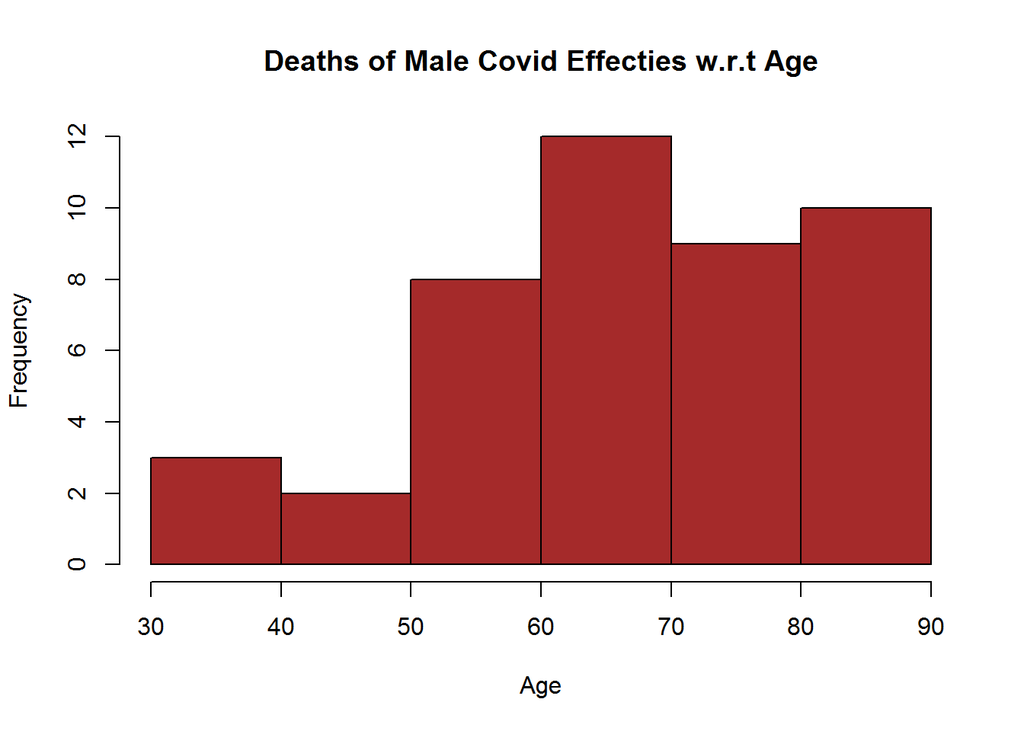

```r
#Gender wise Deaths (Male)

men <- subset(data_copied, gender == "male")
mendeath <- subset(men,death_dummy == 1)
hist(mendeath$age, col='brown',main='Deaths of Male Covid Effecties w.r.t Age',xlab="Age")
```

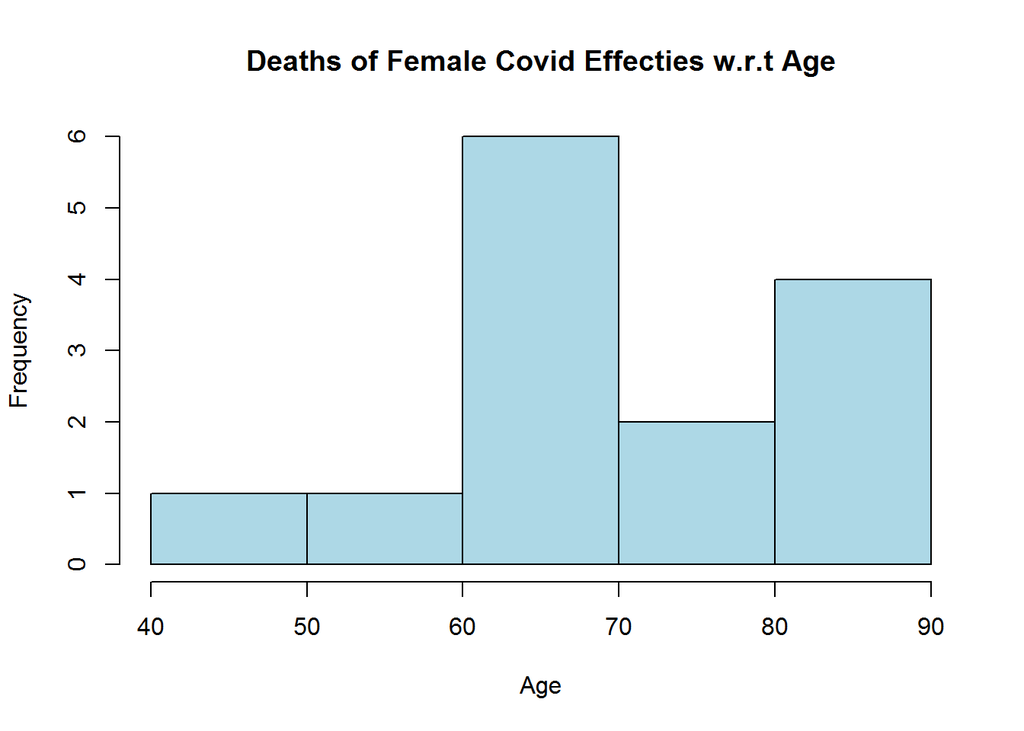

```r
#Gender wise Deaths (Female)

women <- subset(data_copied, gender == "female")
womendeath <- subset(women,death_dummy == 1)
hist(womendeath$age, col='light blue',main='Deaths of Female Covid Effecties w.r.t Age',xlab="Age")
```

```r
#Called Principle Component Analysis on our data

head(data_copied)
```

|  | ï..id | reporting.date | summary | location | country | gender | age | visiting.Wuhan | from.Wuhan | death | recovered | link | death_dummy |
| --- | --- | --- | --- | --- | --- | --- | --- | --- | --- | --- | --- | --- | --- |
| 1 | 1 | 1/20/2020 | First confirmed imported COVID-19 pneumonia patient in Shenzhen (from Wuhan): male, 66, shenzheng residence, visited relatives in Wuhan on 12/29/2019, symptoms onset on 01/03/2020, returned to Shenzhe… | Shenzhen, Guangdong | China | male | 66 | 1 | 0 | 0 | 0 | http://wjw.sz.gov.cn/wzx/202001/t20200120_18987787.htm | 0 |
| 2 | 2 | 1/20/2020 | First confirmed imported COVID-19 pneumonia patient in Shanghai (from Wuhan): female, 56, Wuhan residence, arrived in Shanghai from Wuhan on 01/12/2020, symptom onset and visited fever clinic on 01/15… | Shanghai | China | female | 56 | 0 | 1 | 0 | 0 | https://www.weibo.com/2372649470/IqogQhgfa?from=page_1001062372649470_profile&wvr=6&mod=weibotime&type=comment | 0 |
| 3 | 3 | 1/21/2020 | First confirmed imported cases in Zhejiang: patient is male, 46, lives in Wuhan, self-driving from Wuhan to Hangzhou on 01/03/2020, symptom onset 01/04/2020, hospitalized on 01/17/2020, sample deliver… | Zhejiang | China | male | 46 | 0 | 1 | 0 | 0 | http://www.zjwjw.gov.cn/art/2020/1/21/art_1202101_41786033.html | 0 |
| 4 | 4 | 1/21/2020 | new confirmed imported COVID-19 pneumonia in Tianjin: female, age 60, recently visited Wuhan, visited fever clinic on 01/19/2020 in Tianjin then quarantined immediately. | Tianjin | China | female | 60 | 1 | 0 | 0 | 0 | https://m.weibo.cn/status/4463235401268457? | 0 |
| 5 | 5 | 1/21/2020 | new confirmed imported COVID-19 pneumonia in Tianjin: male, age 58, visited fever clinic on 01/14/2020. | Tianjin | China | male | 58 | 0 | 0 | 0 | 0 | https://m.weibo.cn/status/4463235401268457? | 0 |
| 6 | 6 | 1/21/2020 | First confirmed imported COVID-19 pneumonia patient in Chongqing (from Wuhan): female, age 44, symptoms onset on 01/15/2020, laboratory confirmed on 01/21/2020. | Chongqing | China | female | 44 | 0 | 1 | 0 | 0 | http://wsjkw.cq.gov.cn/tzgg/20200121/249730.html | 0 |

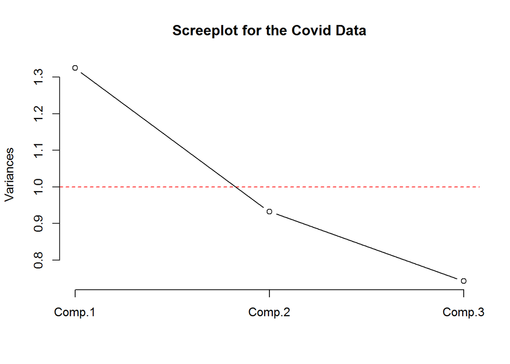

```r
data_copiedpc <- data_copied[,c(7,8,9)]
pc.data <- princomp(data_copiedpc, cor = TRUE)
screeplot(pc.data,type="l", main="Screeplot for the Covid Data")
abline(1,0,col= 'red',lty=2)
```

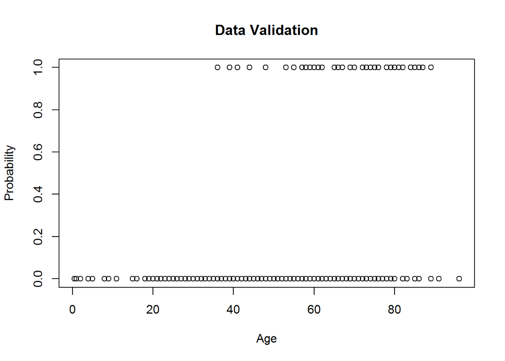

```r
#Regression and Data Validation

death_dummy <- as.integer(data$death !=0)
plot(data_copied$age,data_copied$death_dummy,main="Data Validation",xlab = "Age",ylab = "Probability")
```

Comment: Apart from Regression, above figure shows that the data does not have any error. Patient/effected person is either death due to virus contraction or survived after contracted the virus. Also, it shows that majority of the patients were recovered from virus while the death ones are concentrated in older ages above 35-years.

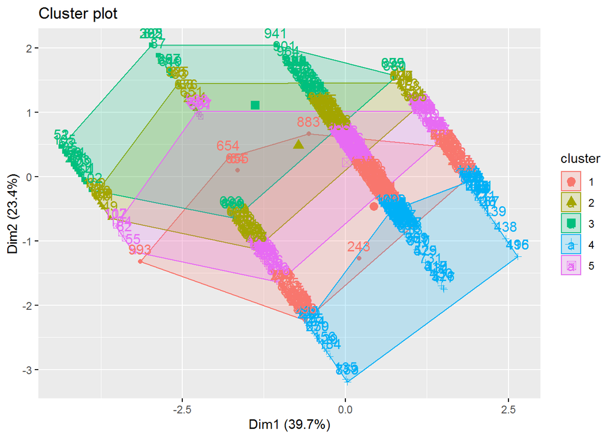

```r
#Clustering of Age, From Wuhan, Visiting Wuhan and Deaths

data_ultra <- select(data_copied,-c(1,2,3,4,5,6,10,11,12))
data_ultra <- na.omit(data_ultra)
km <- kmeans(data_ultra, centers = 5, nstart = 100)
fviz_cluster(km, data = data_ultra)
```

Comment: K-mean clustering shows the deviation of the prescribed 04 principle components from their centroid values i.e. Age, Visiting Wuhan, From Wuhan and Deaths. 5 clusters are made and displayed on right side of the cluster plot. To clean the data that included unoccupied column, we used omit command which ultimately deletes the rows with one or more vacant columns.